# Xây dựng và so sánh các mô hình dự báo vỡ nợ để phát triển hệ thống chấm điểm tín dụng

GiaPhuong

2025-04-27

##Tiền xử lý dữ liệu Nhập dữ liệu

```r
# Load some packages for data manipulation:
library(dplyr)
library(caret)
library(MLmetrics)
library(Information)
library(ROSE)
library(scorecard)
library(ROCR)
library(randomForest)
```

#0. Import data:

```r
### Import data from csv file
df<-read.csv("D:/Tài liệu các môn/Quan tri rui ro dinh luong/Quan_tri_rui_ro2/midtermQTRR2/midtermQTRR2/UCI_Credit_Card.csv")
names(df)[names(df) == "PAY_0"] <- "PAY_1"
head(df)
```

|  | ID | LIMIT_BAL | SEX | EDUCATION | MARRIAGE | AGE | PAY_1 | PAY_2 | PAY_3 | PAY_4 | PAY_5 | PAY_6 | BILL_AMT1 | BILL_AMT2 | BILL_AMT3 | BILL_AMT4 | BILL_AMT5 | BILL_AMT6 | PAY_AMT1 | PAY_AMT2 | PAY_AMT3 | PAY_AMT4 | PAY_AMT5 | PAY_AMT6 | default.payment.next.month |
| --- | --- | --- | --- | --- | --- | --- | --- | --- | --- | --- | --- | --- | --- | --- | --- | --- | --- | --- | --- | --- | --- | --- | --- | --- | --- |
| 1 | 2 | 120000 | 2 | 2 | 2 | 26 | -1 | 2 | 0 | 0 | 0 | 2 | 2682 | 1725 | 2682 | 3272 | 3455 | 3261 | 0 | 1000 | 1000 | 1000 | 0 | 2000 | 1 |
| 2 | 3 | 90000 | 2 | 2 | 2 | 34 | 0 | 0 | 0 | 0 | 0 | 0 | 29239 | 14027 | 13559 | 14331 | 14948 | 15549 | 1518 | 1500 | 1000 | 1000 | 1000 | 5000 | 0 |
| 3 | 6 | 50000 | 1 | 1 | 2 | 37 | 0 | 0 | 0 | 0 | 0 | 0 | 64400 | 57069 | 57608 | 19394 | 19619 | 20024 | 2500 | 1815 | 657 | 1000 | 1000 | 800 | 0 |
| 4 | 9 | 140000 | 2 | 3 | 1 | 28 | 0 | 0 | 2 | 0 | 0 | 0 | 11285 | 14096 | 12108 | 12211 | 11793 | 3719 | 3329 | 0 | 432 | 1000 | 1000 | 1000 | 0 |
| 5 | 11 | 200000 | 2 | 3 | 2 | 34 | 0 | 0 | 2 | 0 | 0 | -1 | 11073 | 9787 | 5535 | 2513 | 1828 | 3731 | 2306 | 12 | 50 | 300 | 3738 | 66 | 0 |
| 6 | 14 | 70000 | 1 | 2 | 2 | 30 | 1 | 2 | 2 | 0 | 0 | 2 | 65802 | 67369 | 65701 | 66782 | 36137 | 36894 | 3200 | 0 | 3000 | 3000 | 1500 | 0 | 1 |

```r
df[] <- lapply(df, as.numeric)
```

```r
df$EDUCATION=ifelse(df$EDUCATION==0,4,ifelse(df$EDUCATION==5,4,ifelse(df$EDUCATION==6,4,ifelse(df$EDUCATION==1,1,ifelse(df$EDUCATION==2,2,ifelse(df$EDUCATION==3,3,4))))))
df$MARRIAGE=ifelse(df$MARRIAGE==0,3,ifelse(df$MARRIAGE==1,1,ifelse(df$MARRIAGE==2,2,3)))
```

```r
# Cập nhật các cột BILL_AMT1 đến BILL_AMT6 nếu giá trị nhỏ hơn 0
df$BILL_AMT1[df$BILL_AMT1 < 0] <- 0
df$BILL_AMT2[df$BILL_AMT2 < 0] <- 0
df$BILL_AMT3[df$BILL_AMT3 < 0] <- 0
df$BILL_AMT4[df$BILL_AMT4 < 0] <- 0
df$BILL_AMT5[df$BILL_AMT5 < 0] <- 0
df$BILL_AMT6[df$BILL_AMT6 < 0] <- 0
```

```r
# Chuẩn hóa các giá trị PAY từ -2, -1 → 0
for (i in 1:6) {
  pay_col <- paste0("PAY_", i)
  df[[pay_col]][df[[pay_col]] %in% c(-2, -1)] <- 0
}

# Kiểm tra xem có data bị gán sai hay không
sum(df$PAY_1 == 0 & df$PAY_2 == 0 & df$PAY_3 == 0 &
    df$PAY_4 == 0 & df$PAY_5 == 0 & df$PAY_6 == 0 &
    df$default.payment.next.month == 1)
```

```
## [1] 237
```

```r
# Sửa nhãn default nếu không nợ tháng nào nhưng bị gán sai
df$default.payment.next.month[
  df$PAY_1 == 0 & df$PAY_2 == 0 & df$PAY_3 == 0 &
  df$PAY_4 == 0 & df$PAY_5 == 0 & df$PAY_6 == 0 &
  df$default.payment.next.month == 1
] <- 0

# Sửa nhãn default nếu nợ cả 6 tháng nhưng bị gán sai
df$default.payment.next.month[
  df$PAY_1 > 0 & df$PAY_2 > 0 & df$PAY_3 > 0 &
  df$PAY_4 > 0 & df$PAY_5 > 0 & df$PAY_6 > 0 &
  df$default.payment.next.month == 0
] <- 1
```

```r
df$SEX <- as.factor(df$SEX)
df$EDUCATION <- as.factor(df$EDUCATION)
df$MARRIAGE <- as.factor(df$MARRIAGE)
```

#1. Preprocessing data #1.1. Descriptive statistic

```r
### Descriptive statistic
summary(df)
```

```
##        ID          LIMIT_BAL      SEX      EDUCATION MARRIAGE      AGE
##  Min.   :    2   Min.   : 10000   1:3974   1:2919    1:4342   Min.   :21.0
##  1st Qu.: 7358   1st Qu.: 50000   2:6026   2:5108    2:5517   1st Qu.:27.0
##  Median :14760   Median : 80000            3:1862    3: 141   Median :33.0
##  Mean   :14801   Mean   :119748            4: 111             Mean   :34.8
##  3rd Qu.:21999   3rd Qu.:170000                               3rd Qu.:41.0
##  Max.   :29997   Max.   :500000                               Max.   :60.0
##      PAY_1            PAY_2            PAY_3            PAY_4
##  Min.   :0.0000   Min.   :0.0000   Min.   :0.0000   Min.   :0.0000
##  1st Qu.:0.0000   1st Qu.:0.0000   1st Qu.:0.0000   1st Qu.:0.0000
##  Median :0.0000   Median :0.0000   Median :0.0000   Median :0.0000
##  Mean   :0.3959   Mean   :0.4158   Mean   :0.3948   Mean   :0.3398
##  3rd Qu.:0.0000   3rd Qu.:0.0000   3rd Qu.:0.0000   3rd Qu.:0.0000
##  Max.   :8.0000   Max.   :7.0000   Max.   :8.0000   Max.   :8.0000
##      PAY_5            PAY_6          BILL_AMT1        BILL_AMT2
##  Min.   :0.0000   Min.   :0.0000   Min.   :     0   Min.   :     0
##  1st Qu.:0.0000   1st Qu.:0.0000   1st Qu.:  9861   1st Qu.:  9629
##  Median :0.0000   Median :0.0000   Median : 29503   Median : 28714
##  Mean   :0.2922   Mean   :0.2976   Mean   : 42330   Mean   : 40819
##  3rd Qu.:0.0000   3rd Qu.:0.0000   3rd Qu.: 63442   3rd Qu.: 60770
##  Max.   :8.0000   Max.   :8.0000   Max.   :189003   Max.   :182435
##    BILL_AMT3        BILL_AMT4        BILL_AMT5        BILL_AMT6
##  Min.   :     0   Min.   :     0   Min.   :     0   Min.   :     0
##  1st Qu.:  9582   1st Qu.:  9082   1st Qu.:  8175   1st Qu.:  6244
##  Median : 27555   Median : 24905   Median : 21805   Median : 20205
##  Mean   : 38797   Mean   : 35729   Mean   : 33349   Mean   : 31969
##  3rd Qu.: 56474   3rd Qu.: 50804   3rd Qu.: 48672   3rd Qu.: 47729
##  Max.   :173325   Max.   :161573   Max.   :151194   Max.   :146194
##     PAY_AMT1        PAY_AMT2        PAY_AMT3          PAY_AMT4
##  Min.   :    0   Min.   :    0   Min.   :    0.0   Min.   :    0
##  1st Qu.: 1300   1st Qu.: 1237   1st Qu.:  915.8   1st Qu.:  619
##  Median : 2000   Median : 2000   Median : 1700.0   Median : 1500
##  Mean   : 2646   Mean   : 2543   Mean   : 2201.0   Mean   : 1991
##  3rd Qu.: 3600   3rd Qu.: 3455   3rd Qu.: 3000.0   3rd Qu.: 3000
##  Max.   :11662   Max.   :11236   Max.   :11000.0   Max.   :10902
##     PAY_AMT5        PAY_AMT6     default.payment.next.month
##  Min.   :    0   Min.   :    0   Min.   :0.0000
##  1st Qu.:  600   1st Qu.:  500   1st Qu.:0.0000
##  Median : 1500   Median : 1382   Median :0.0000
##  Mean   : 1987   Mean   : 1917   Mean   :0.1763
##  3rd Qu.: 3000   3rd Qu.: 3000   3rd Qu.:0.0000
##  Max.   :10800   Max.   :10400   Max.   :1.0000
```

#1.2. Xem biến trạng thái BAD (1, 0)

```r
#Tính default rate để đánh giá tính cân bằng của dữ liệu
table(df$default.payment.next.month)
```

```
##
##    0    1
## 8237 1763
```

```r
prop.table(table(df$default.payment.next.month))
```

```
##
##      0      1
## 0.8237 0.1763
```

#1.3. Xử lý giá trị missing/outliers

```r
# Check NA
colSums(is.na(df))
```

```
##                         ID                  LIMIT_BAL
##                          0                          0
##                        SEX                  EDUCATION
##                          0                          0
##                   MARRIAGE                        AGE
##                          0                          0
##                      PAY_1                      PAY_2
##                          0                          0
##                      PAY_3                      PAY_4
##                          0                          0
##                      PAY_5                      PAY_6
##                          0                          0
##                  BILL_AMT1                  BILL_AMT2
##                          0                          0
##                  BILL_AMT3                  BILL_AMT4
##                          0                          0
##                  BILL_AMT5                  BILL_AMT6
##                          0                          0
##                   PAY_AMT1                   PAY_AMT2
##                          0                          0
##                   PAY_AMT3                   PAY_AMT4
##                          0                          0
##                   PAY_AMT5                   PAY_AMT6
##                          0                          0
## default.payment.next.month
##                          0
```

```r
# Hàm để phát hiện outlier bằng IQR
detect_outliers <- function(x) {
  Q1 <- quantile(x, 0.25)
  Q3 <- quantile(x, 0.75)
  IQR <- Q3 - Q1
  lower_bound <- Q1 - 1.5 * IQR
  upper_bound <- Q3 + 1.5 * IQR
  return(x < lower_bound | x > upper_bound)
}

numeric_vars <- sapply(df, is.numeric)  # chọn các biến dạng numeric
numeric_vars <- setdiff(names(df)[numeric_vars], c("ID","default.payment.next.month","PAY_1","PAY_2","PAY_3","PAY_4","PAY_5","PAY_6"))
# Áp dụng hàm detect_outliers
outliers_IQR <- sapply(df[, numeric_vars], detect_outliers)

# Kiểm tra số lượng outliers cho từng cột
outliers_count_IQR <- colSums(outliers_IQR)
outliers_count_IQR
```

```
## LIMIT_BAL       AGE BILL_AMT1 BILL_AMT2 BILL_AMT3 BILL_AMT4 BILL_AMT5 BILL_AMT6
##       419         0       255       257       379       443       433       395
##  PAY_AMT1  PAY_AMT2  PAY_AMT3  PAY_AMT4  PAY_AMT5  PAY_AMT6
##       419       464       447       334       318       290
```

```r
# Xác định các quan sát (dòng) có chứa outliers
rows_with_outliers <- apply(outliers_IQR, 1, any)

# Loại bỏ các quan sát có outliers
df <- df[!rows_with_outliers, ]

# Kiểm tra kết quả
dim(df)  # Kiểm tra số dòng còn lại sau khi loại bỏ outliers
```

```
## [1] 7726   25
```

```r
#Kiem tra lai tinh can bang cua du lieu
table(df$default.payment.next.month)
```

```
##
##    0    1
## 6229 1497
```

```r
prop.table(table(df$default.payment.next.month))
```

```
##
##         0         1
## 0.8062387 0.1937613
```

```r
IV <- Information::create_infotables(data = df[, !(names(df) %in% c("ID"))], y = "default.payment.next.month", parallel = FALSE)
print(IV$Summary)
```

```
##     Variable          IV
## 6      PAY_1 2.490809091
## 7      PAY_2 1.548249614
## 8      PAY_3 1.200711755
## 9      PAY_4 1.122120920
## 10     PAY_5 1.016745088
## 11     PAY_6 0.906301522
## 1  LIMIT_BAL 0.278846515
## 18  PAY_AMT1 0.238947350
## 19  PAY_AMT2 0.195329170
## 20  PAY_AMT3 0.156165192
## 21  PAY_AMT4 0.151775262
## 12 BILL_AMT1 0.138285497
## 23  PAY_AMT6 0.120009712
## 13 BILL_AMT2 0.111588136
## 22  PAY_AMT5 0.105015370
## 14 BILL_AMT3 0.098006704
## 17 BILL_AMT6 0.087024061
## 16 BILL_AMT5 0.080596107
## 15 BILL_AMT4 0.072426159
## 3  EDUCATION 0.048253930
## 5        AGE 0.011494196
## 4   MARRIAGE 0.005743162
## 2        SEX 0.001943302
```

#Loại các biến có IV nhỏ hơn 0.02

```r
# select vars of IV < 0.02
vars_removed <- IV$Summary %>% as.data.frame %>%
                                    subset(IV < 0.02) %>% pull(1)
vars_removed
```

```
## [1] "AGE"      "MARRIAGE" "SEX"
```

#Tạo dữ liệu sau khi lọc biến

```r
data <- df %>% dplyr::select(-all_of(c(vars_removed, "ID")))
```

#Chia tập dữ liệu train và test:

```r
set.seed(10)
trainIndex <- createDataPartition(data$default.payment.next.month, p = 0.7, list = FALSE)
train.data <- data[trainIndex, ]
test.data <- data[-trainIndex, ]
```

#CHAY MO HINH LOGIT VOI BIEN GOC

```r
logit.model1 <- glm(default.payment.next.month ~ ., family = binomial(link = 'logit'), data = train.data)
summary(logit.model1)
```

```
##
## Call:
## glm(formula = default.payment.next.month ~ ., family = binomial(link = "logit"),
##     data = train.data)
##
## Coefficients:
##               Estimate Std. Error z value Pr(>|z|)
## (Intercept) -2.899e+00  1.830e-01 -15.839  < 2e-16 ***
## LIMIT_BAL   -8.849e-07  8.166e-07  -1.084  0.27850
## EDUCATION2  -5.200e-02  1.248e-01  -0.417  0.67695
## EDUCATION3  -1.049e-01  1.507e-01  -0.696  0.48663
## EDUCATION4  -1.667e+00  1.050e+00  -1.587  0.11249
## PAY_1        1.477e+00  6.646e-02  22.228  < 2e-16 ***
## PAY_2        2.250e-01  8.033e-02   2.801  0.00509 **
## PAY_3        1.725e-01  9.330e-02   1.849  0.06440 .
## PAY_4        4.856e-01  9.278e-02   5.233 1.66e-07 ***
## PAY_5        3.109e-01  9.543e-02   3.257  0.00112 **
## PAY_6        5.208e-01  7.962e-02   6.541 6.10e-11 ***
## BILL_AMT1   -2.066e-05  9.863e-06  -2.094  0.03624 *
## BILL_AMT2    2.455e-05  1.231e-05   1.994  0.04613 *
## BILL_AMT3   -1.208e-05  1.036e-05  -1.165  0.24386
## BILL_AMT4    1.513e-05  9.770e-06   1.549  0.12150
## BILL_AMT5   -2.143e-05  1.229e-05  -1.744  0.08120 .
## BILL_AMT6    1.549e-05  1.057e-05   1.466  0.14268
## PAY_AMT1    -7.233e-05  5.348e-05  -1.352  0.17623
## PAY_AMT2    -2.616e-05  5.225e-05  -0.501  0.61655
## PAY_AMT3     1.668e-07  5.692e-05   0.003  0.99766
## PAY_AMT4    -3.287e-07  5.682e-05  -0.006  0.99538
## PAY_AMT5    -3.767e-05  5.172e-05  -0.728  0.46636
## PAY_AMT6    -5.672e-05  4.793e-05  -1.183  0.23664
## ---
## Signif. codes:  0 '***' 0.001 '**' 0.01 '*' 0.05 '.' 0.1 ' ' 1
##
## (Dispersion parameter for binomial family taken to be 1)
##
##     Null deviance: 5312.6  on 5408  degrees of freedom
## Residual deviance: 2741.7  on 5386  degrees of freedom
## AIC: 2787.7
##
## Number of Fisher Scoring iterations: 6
```

#Lọc biến mô hình logit (voi bien goc) theo stepwise

```r
logit.step1 <- step(logit.model1, direction = "backward", trace = 0)
summary(logit.step1)
```

```
##
## Call:
## glm(formula = default.payment.next.month ~ PAY_1 + PAY_2 + PAY_3 +
##     PAY_4 + PAY_5 + PAY_6 + BILL_AMT1 + BILL_AMT2 + BILL_AMT5 +
##     BILL_AMT6 + PAY_AMT1 + PAY_AMT6, family = binomial(link = "logit"),
##     data = train.data)
##
## Coefficients:
##               Estimate Std. Error z value Pr(>|z|)
## (Intercept) -3.080e+00  1.215e-01 -25.358  < 2e-16 ***
## PAY_1        1.481e+00  6.575e-02  22.525  < 2e-16 ***
## PAY_2        2.261e-01  7.913e-02   2.857  0.00427 **
## PAY_3        2.037e-01  8.248e-02   2.469  0.01354 *
## PAY_4        4.648e-01  7.249e-02   6.411 1.44e-10 ***
## PAY_5        3.187e-01  7.920e-02   4.024 5.73e-05 ***
## PAY_6        5.398e-01  6.912e-02   7.810 5.73e-15 ***
## BILL_AMT1   -2.258e-05  9.862e-06  -2.290  0.02202 *
## BILL_AMT2    2.332e-05  1.087e-05   2.146  0.03188 *
## BILL_AMT5   -1.683e-05  1.087e-05  -1.548  0.12152
## BILL_AMT6    1.497e-05  9.944e-06   1.506  0.13217
## PAY_AMT1    -7.318e-05  5.130e-05  -1.427  0.15366
## PAY_AMT6    -7.132e-05  4.531e-05  -1.574  0.11546
## ---
## Signif. codes:  0 '***' 0.001 '**' 0.01 '*' 0.05 '.' 0.1 ' ' 1
##
## (Dispersion parameter for binomial family taken to be 1)
##
##     Null deviance: 5312.6  on 5408  degrees of freedom
## Residual deviance: 2751.1  on 5396  degrees of freedom
## AIC: 2777.1
##
## Number of Fisher Scoring iterations: 6
```

#Validate mô hình - confusionMatrix trên tập train

```r
train.prob1 <- predict(logit.step1, type = "response")
train.pred1 <- ifelse(train.prob1 > 0.5, "1", "0")
table.train1<-table(train.pred1, train.data$default.payment.next.month)
table.train1
```

```
##
## train.pred1    0    1
##           0 4146  409
##           1  217  637
```

```r
confusionMatrix.train1<-prop.table(table.train1)
confusionMatrix.train1
```

```
##
## train.pred1          0          1
##           0 0.76650028 0.07561472
##           1 0.04011832 0.11776669
```

#Validate mô hình - confusionMatrix trên tập test

```r
test.prob1 <- predict(logit.step1, test.data, type = 'response')
test.pred1<- as.factor(ifelse(test.prob1 > 0.5, 1, 0))
table.test1<-table(test.pred1, test.data$default.payment.next.month)
table.test1
```

```
##
## test.pred1    0    1
##          0 1763  213
##          1  103  238
```

```r
confusionMatrix.test1<-prop.table(table.test1)
confusionMatrix.test1
```

```
##
## test.pred1          0          1
##          0 0.76089771 0.09192922
##          1 0.04445404 0.10271903
```

#Chỉ tiêu khác

```r
sensitivity(test.pred1, factor(test.data$default.payment.next.month, levels = c(0,1)),positive="1")
```

```
## [1] 0.5277162
```

```r
specificity(test.pred1, factor(test.data$default.payment.next.month, levels = c(0,1)),negative="0")
```

```
## [1] 0.9448017
```

#vẽ đường cong ROC

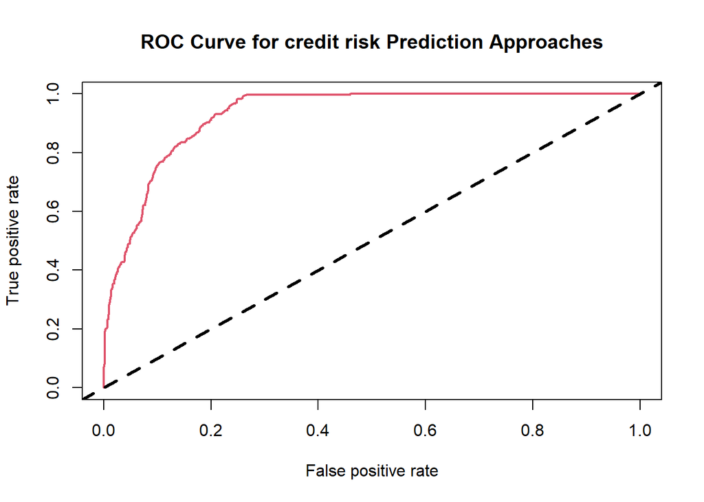

```r
# Logistic Regression ROC curve
roc.pred1 <- prediction(predictions = test.prob1, labels = test.data$default.payment.next.month)
roc.perf1 <- performance(roc.pred1, measure = "tpr", x.measure = "fpr")
# Tính chỉ số AUROC
AUROC_value1 <- roc.perf1@y.values[[1]]
auc1 <- as.numeric(performance(roc.pred1, measure = "auc")@y.values)
plot(roc.perf1, main = "ROC Curve for credit risk Prediction Approaches", col = 2, lwd = 2)
abline(a = 0, b = 1, lwd = 3, lty = 2, col = 1)
```

```r
auc1
```

```
## [1] 0.9298884
```

```r
# Tính chỉ số AUROC và GINI
auc1 <- as.numeric(performance(roc.pred1, measure = "auc")@y.values)
auc1
```

```
## [1] 0.9298884
```

```r
gini1 <- 2*auc1 - 1
gini1
```

```
## [1] 0.8597769
```

#CHAY MO HINH LOGIT VOI BIEN WOE

#Bin các biến theo woe:

```r
bins <- woebin(train.data, y = "default.payment.next.month")
```

```
## ℹ Creating woe binning ...
```

```
## ✔ Binning on 5409 rows and 21 columns in 00:00:07
```

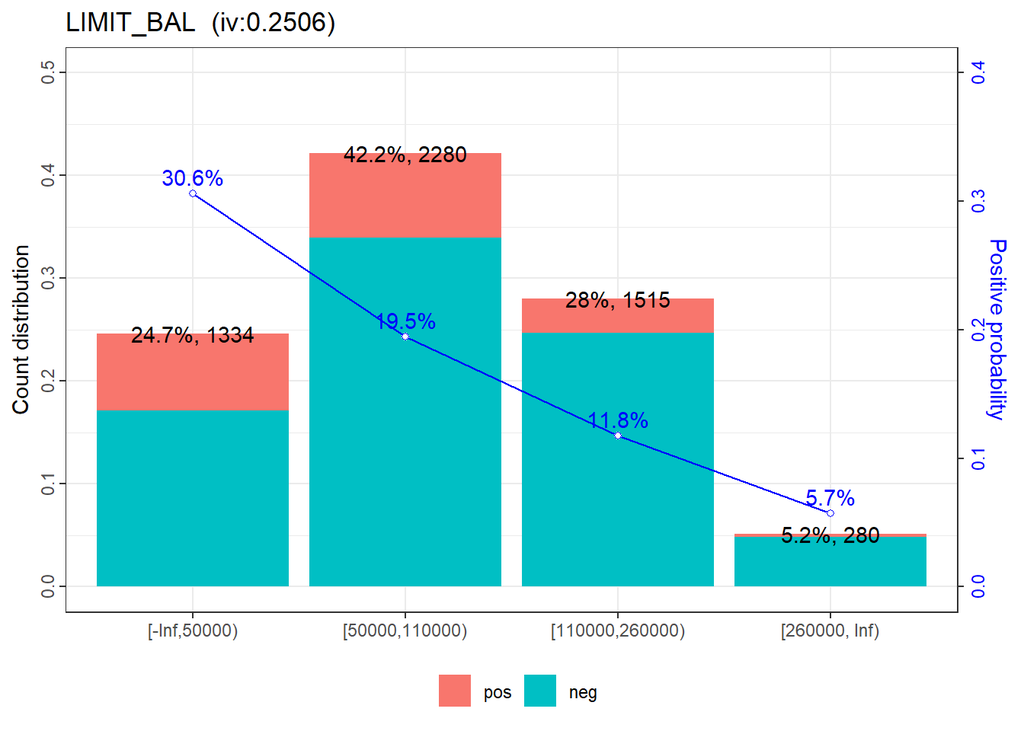

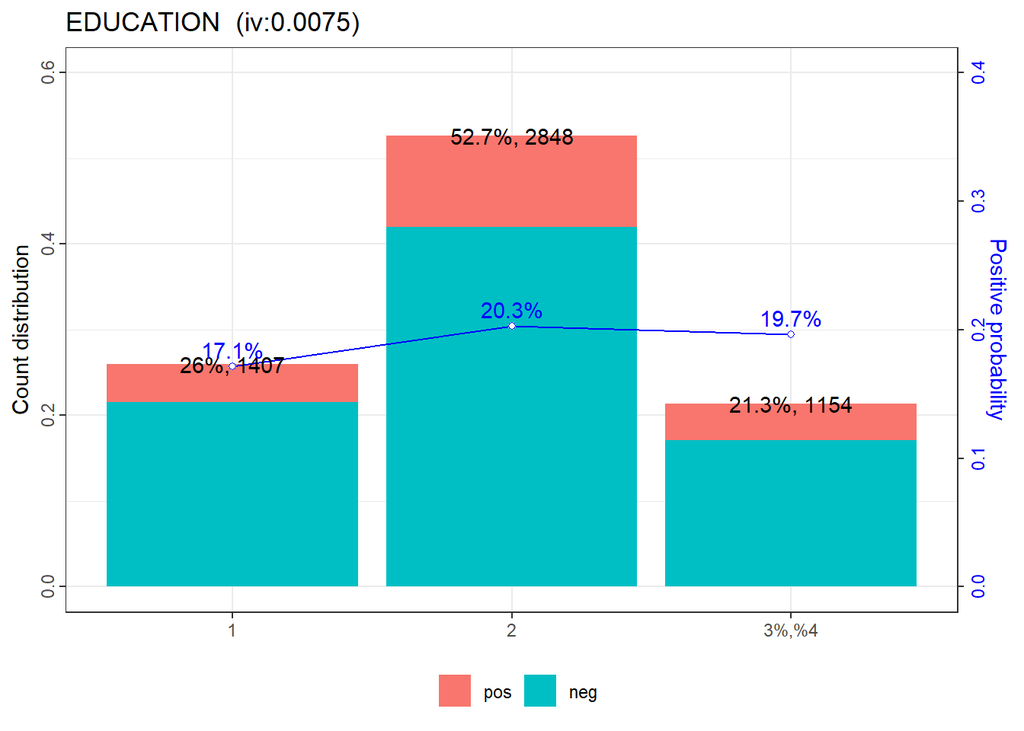

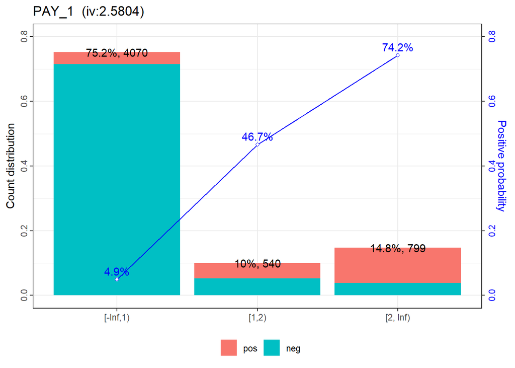

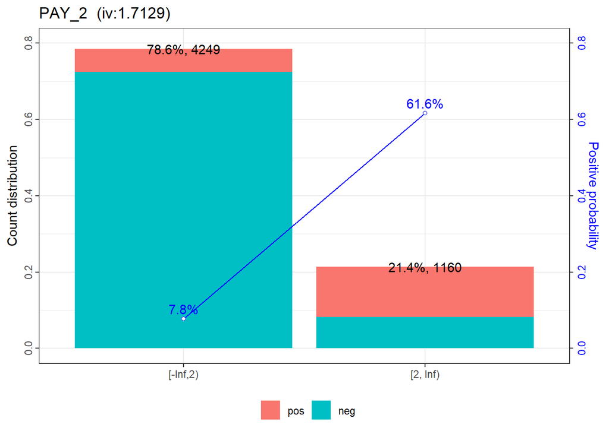

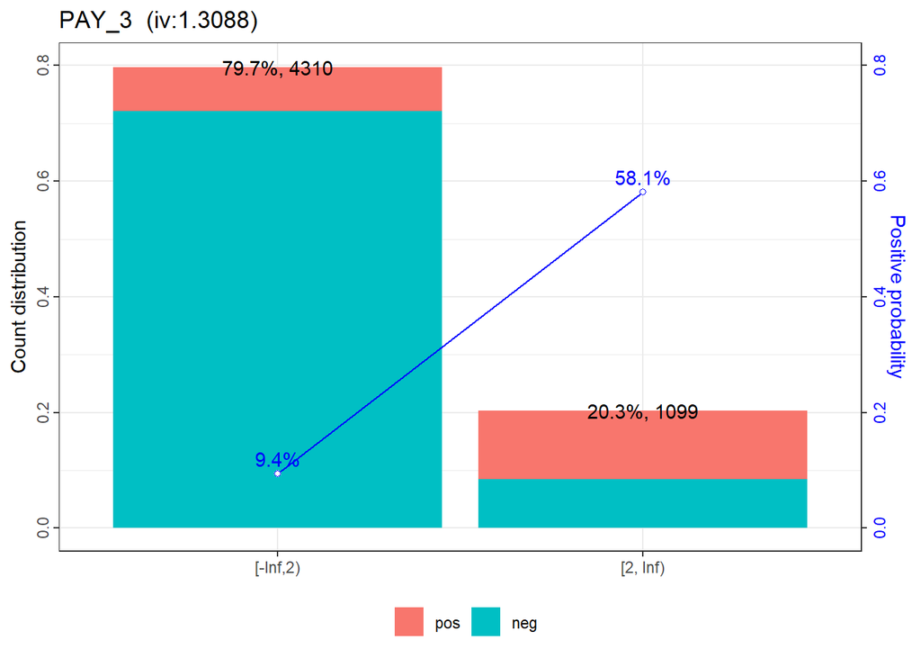

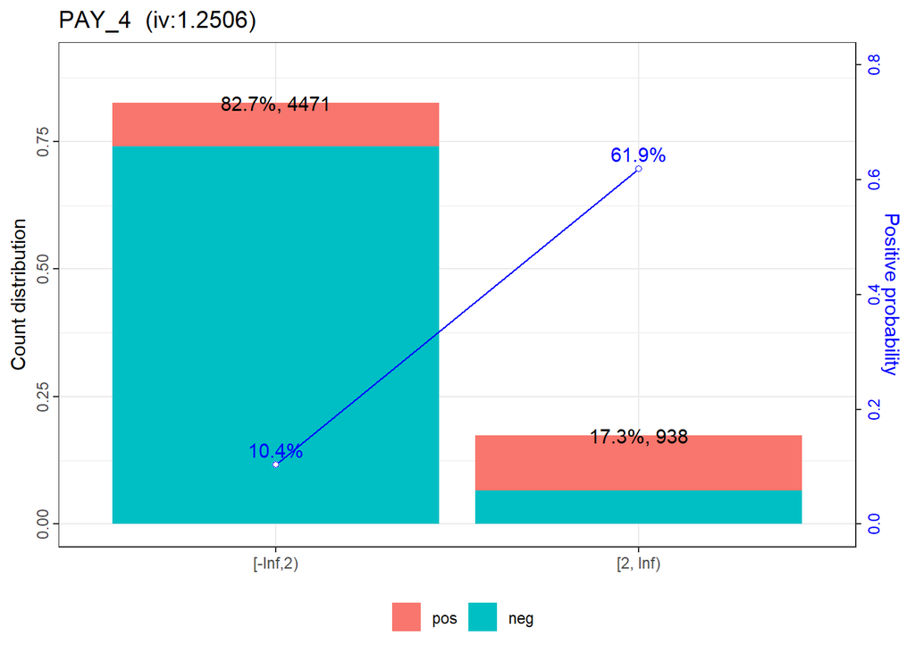

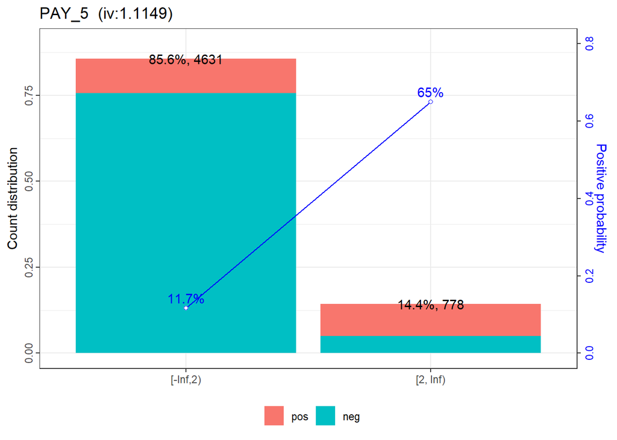

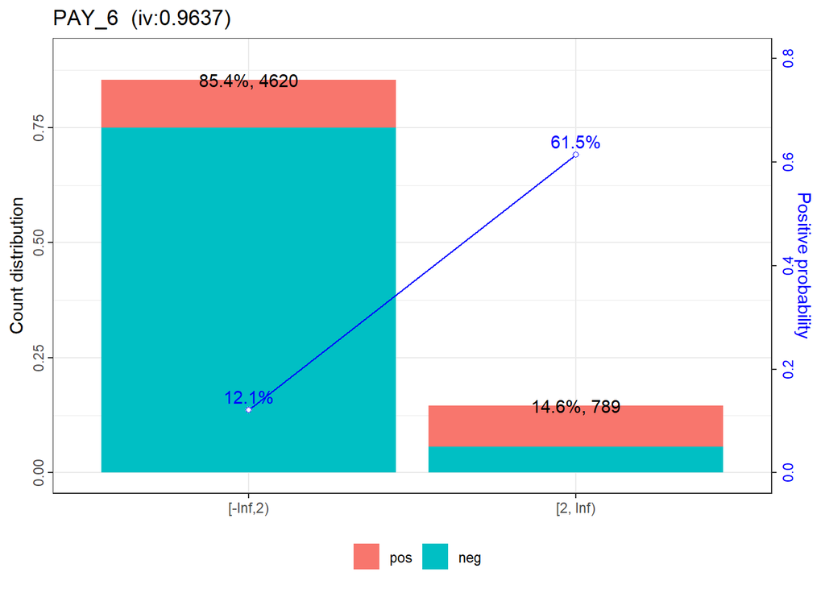

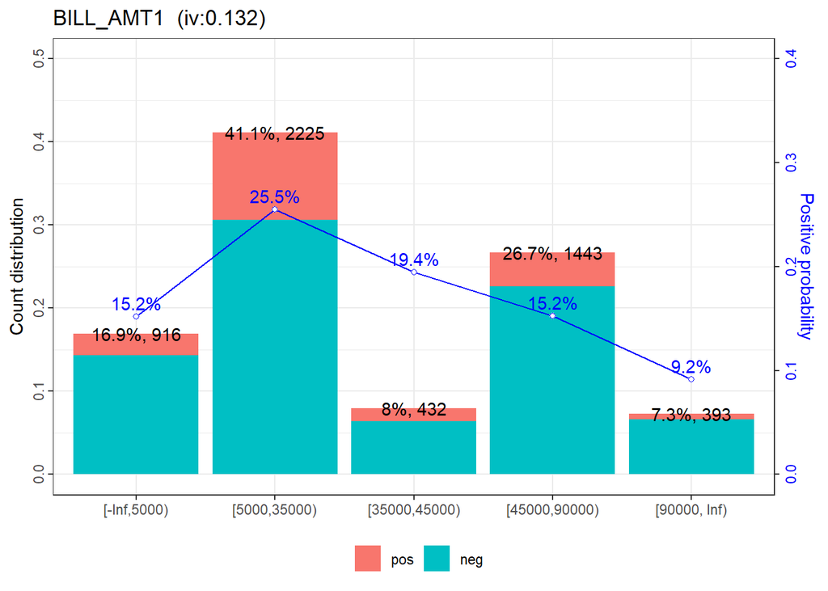

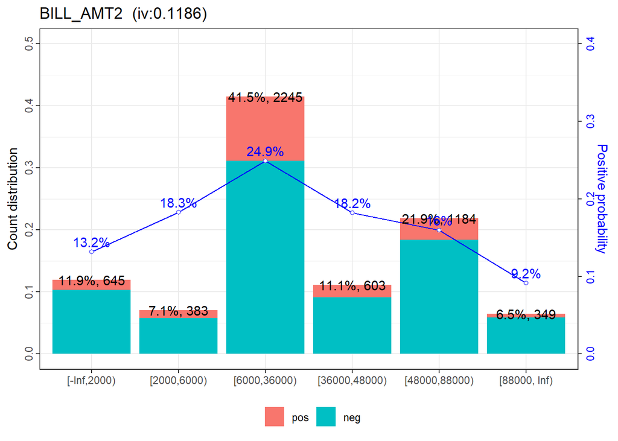

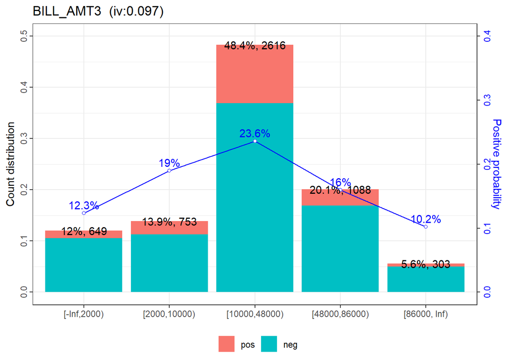

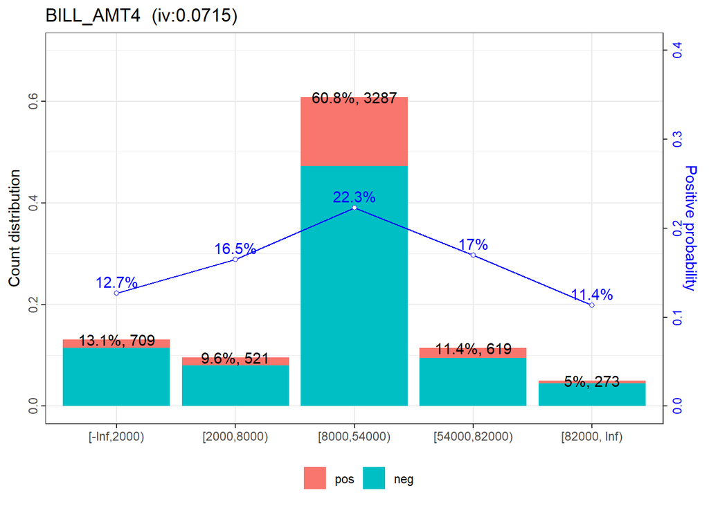

[8 more figures not shown]

```r
woebin_plot(bins)
```

Thực hiện trên tập train:

```r
train.data_woe <- woebin_ply(train.data, bins)
```

```
## ℹ Converting into woe values ...
```

```
## ✔ Woe transformating on 5409 rows and 20 columns in 00:00:02
```

```r
logit.model2 <- glm(default.payment.next.month ~., family = binomial(link = 'logit'), data = train.data_woe)
summary(logit.model2)
```

```
##
## Call:
## glm(formula = default.payment.next.month ~ ., family = binomial(link = "logit"),
##     data = train.data_woe)
##
## Coefficients:
##               Estimate Std. Error z value Pr(>|z|)
## (Intercept)   -1.41778    0.05356 -26.472  < 2e-16 ***
## LIMIT_BAL_woe  0.22950    0.12115   1.894 0.058179 .
## EDUCATION_woe -0.07626    0.60783  -0.125 0.900155
## PAY_1_woe      0.82521    0.03620  22.798  < 2e-16 ***
## PAY_2_woe     -0.03312    0.06258  -0.529 0.596647
## PAY_3_woe      0.18895    0.07370   2.564 0.010351 *
## PAY_4_woe      0.27054    0.07271   3.721 0.000199 ***
## PAY_5_woe      0.24894    0.07867   3.164 0.001555 **
## PAY_6_woe      0.50265    0.06938   7.245 4.32e-13 ***
## BILL_AMT1_woe -0.01847    0.32111  -0.058 0.954125
## BILL_AMT2_woe -0.20178    0.38446  -0.525 0.599699
## BILL_AMT3_woe  0.06048    0.32925   0.184 0.854265
## BILL_AMT4_woe -0.17914    0.44449  -0.403 0.686935
## BILL_AMT5_woe  0.11800    0.43024   0.274 0.783881
## BILL_AMT6_woe  0.23044    0.30535   0.755 0.450444
## PAY_AMT1_woe   0.23051    0.09463   2.436 0.014857 *
## PAY_AMT2_woe   0.16176    0.10638   1.521 0.128364
## PAY_AMT3_woe   0.30374    0.10576   2.872 0.004080 **
## PAY_AMT4_woe   0.14996    0.11849   1.266 0.205654
## PAY_AMT5_woe   0.01912    0.14289   0.134 0.893555
## PAY_AMT6_woe   0.21414    0.14424   1.485 0.137654
## ---
## Signif. codes:  0 '***' 0.001 '**' 0.01 '*' 0.05 '.' 0.1 ' ' 1
##
## (Dispersion parameter for binomial family taken to be 1)
##
##     Null deviance: 5312.6  on 5408  degrees of freedom
## Residual deviance: 2667.3  on 5388  degrees of freedom
## AIC: 2709.3
##
## Number of Fisher Scoring iterations: 6
```

#Lọc biến mô hình logit theo stepwise

```r
logit.step2 <- step(logit.model2, direction = "backward", trace = 0)
summary(logit.step2)
```

```
##
## Call:
## glm(formula = default.payment.next.month ~ LIMIT_BAL_woe + PAY_1_woe +
##     PAY_3_woe + PAY_4_woe + PAY_5_woe + PAY_6_woe + PAY_AMT1_woe +
##     PAY_AMT2_woe + PAY_AMT3_woe + PAY_AMT6_woe, family = binomial(link = "logit"),
##     data = train.data_woe)
##
## Coefficients:
##               Estimate Std. Error z value Pr(>|z|)
## (Intercept)   -1.41516    0.05336 -26.519  < 2e-16 ***
## LIMIT_BAL_woe  0.19019    0.10504   1.811 0.070209 .
## PAY_1_woe      0.81925    0.03118  26.271  < 2e-16 ***
## PAY_3_woe      0.16905    0.06600   2.561 0.010431 *
## PAY_4_woe      0.26279    0.07162   3.669 0.000243 ***
## PAY_5_woe      0.30245    0.06472   4.674 2.96e-06 ***
## PAY_6_woe      0.48200    0.05911   8.155 3.50e-16 ***
## PAY_AMT1_woe   0.19833    0.07153   2.772 0.005563 **
## PAY_AMT2_woe   0.17602    0.10568   1.666 0.095804 .
## PAY_AMT3_woe   0.31330    0.10274   3.049 0.002293 **
## PAY_AMT6_woe   0.22177    0.13895   1.596 0.110476
## ---
## Signif. codes:  0 '***' 0.001 '**' 0.01 '*' 0.05 '.' 0.1 ' ' 1
##
## (Dispersion parameter for binomial family taken to be 1)
##
##     Null deviance: 5312.6  on 5408  degrees of freedom
## Residual deviance: 2671.5  on 5398  degrees of freedom
## AIC: 2693.5
##
## Number of Fisher Scoring iterations: 6
```

#Validate mô hình - confusionMatrix trên tập train

```r
train.prob2 <- predict(logit.step2, type = "response")
train.pred2 <- ifelse(train.prob2 > 0.5, "1", "0")
table.train2<-table(train.pred2, train.data$default.payment.next.month)
table.train2
```

```
##
## train.pred2    0    1
##           0 4132  397
##           1  231  649
```

```r
confusionMatrix.train2<-prop.table(table.train2)
confusionMatrix.train2
```

```
##
## train.pred2          0          1
##           0 0.76391200 0.07339619
##           1 0.04270660 0.11998521
```

#Validate mô hình - confusionMatrix trên tập test

#Chuyển dữ liệu theo woe

```r
test.data_woe <- woebin_ply(test.data, bins)
```

```
## ℹ Converting into woe values ...
```

```
## ✔ Woe transformating on 2317 rows and 20 columns in 00:00:02
```

```r
head(test.data_woe)
```

| default.payment.next.month | LIMIT_BAL_woe | EDUCATION_woe | PAY_1_woe | PAY_2_woe | PAY_3_woe | PAY_4_woe | PAY_5_woe | PAY_6_woe | BILL_AMT1_woe | BILL_AMT2_woe | BILL_AMT3_woe | BILL_AMT4_woe | BILL_AMT5_woe | BILL_AMT6_woe | PAY_AMT1_woe | PAY_AMT2_woe | PAY_AMT3_woe | PAY_AMT4_woe | PAY_AMT5_woe | PAY_AMT6_woe |
| --- | --- | --- | --- | --- | --- | --- | --- | --- | --- | --- | --- | --- | --- | --- | --- | --- | --- | --- | --- | --- |
| 0 | 0.00866652 | 0.06022529 | -1.529260 | -1.043032 | -0.8325011 | -0.7253246 | -0.596789 | -0.5507845 | 0.3551785 | 0.32660247 | 0.2547730 | 0.1816711 | 0.2013990 | 0.2602395 | -0.4068661 | -0.2504154 | -0.2006816 | -0.1344896 | -0.0568581 | -0.40777903 |
| 0 | 0.00866652 | -0.14835090 | -1.529260 | -1.043032 | -0.8325011 | -0.7253246 | -0.596789 | -0.5507845 | -0.2872481 | -0.23280919 | -0.2305887 | 0.1816711 | 0.2013990 | 0.2602395 | -0.1967656 | -0.2504154 | -0.2006816 | -0.1344896 | -0.0568581 | -0.08204473 |
| 0 | -0.58821350 | 0.02118298 | -1.529260 | -1.043032 | 1.7568645 | -0.7253246 | -0.596789 | -0.5507845 | 0.3551785 | 0.32660247 | 0.2547730 | 0.1816711 | 0.2013990 | -0.4278080 | -0.1967656 | 1.3696182 | -1.0681488 | -0.1344896 | -0.0568581 | -0.08204473 |
| 0 | -0.58821350 | -0.14835090 | -1.529260 | -1.043032 | -0.8325011 | -0.7253246 | -0.596789 | -0.5507845 | -0.2872481 | -0.23280919 | -0.2305887 | -0.1600764 | -0.1935215 | -0.2359274 | -0.1967656 | -0.2504154 | -0.2006816 | -0.3997942 | -0.4010305 | -0.40777903 |
| 0 | 0.00866652 | 0.02118298 | -1.529260 | -1.043032 | -0.8325011 | -0.7253246 | -0.596789 | -0.5507845 | -0.2872481 | -0.07184228 | 0.2547730 | 0.1816711 | 0.2013990 | 0.2602395 | -0.4068661 | -0.2504154 | -0.2006816 | -0.1344896 | -0.0568581 | -0.08204473 |
| 0 | -0.58821350 | -0.14835090 | 2.485505 | -1.043032 | -0.8325011 | -0.7253246 | -0.596789 | -0.5507845 | -0.2927799 | -0.45709900 | -0.5336673 | -0.1928122 | -0.4089746 | -0.4278080 | -0.4068661 | -0.2504154 | -0.2006816 | -0.9977218 | -0.4010305 | -0.08204473 |

#confusionMatrix

```r
test.prob2 <- predict(logit.step2, test.data_woe, type = 'response')
test.pred2<- as.factor(ifelse(test.prob2 > 0.5, 1, 0))
table.test2<-table(test.pred2, test.data$default.payment.next.month)
table.test2
```

```
##
## test.pred2    0    1
##          0 1751  205
##          1  115  246
```

```r
confusionMatrix.test2<-prop.table(table.test2)
confusionMatrix.test2
```

```
##
## test.pred2          0          1
##          0 0.75571860 0.08847648
##          1 0.04963315 0.10617177
```

#Chỉ tiêu khác

```r
sensitivity(test.pred2, factor(test.data$default.payment.next.month, levels = c(0,1)),positive="1")
```

```
## [1] 0.5454545
```

```r
specificity(test.pred2, factor(test.data$default.payment.next.month, levels = c(0,1)),negative="0")
```

```
## [1] 0.9383708
```

#vẽ đường cong ROC

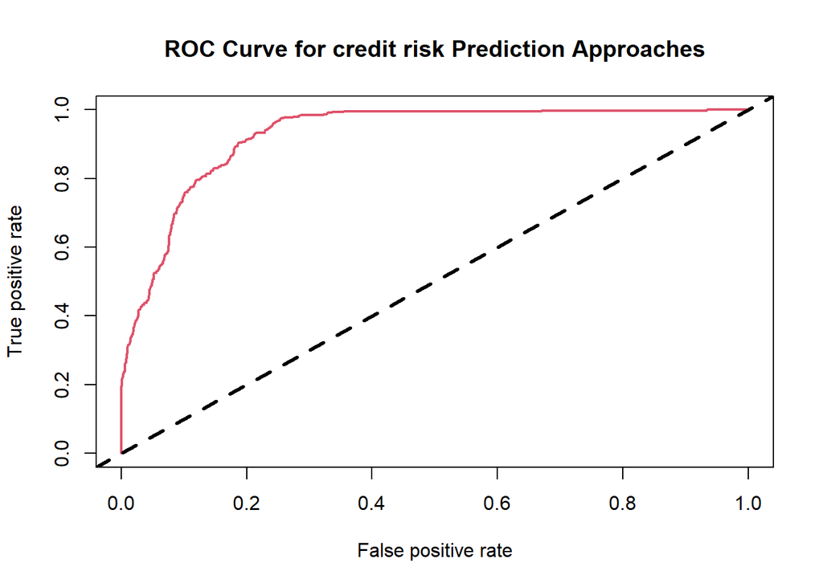

```r
# Logistic Regression ROC curve
roc.pred2 <- prediction(predictions = test.prob2, labels = test.data$default.payment.next.month)
roc.perf2 <- performance(roc.pred2, measure = "tpr", x.measure = "fpr")
# Tính chỉ số AUROC
AUROC_value2 <- roc.perf2@y.values[[1]]
auc2 <- as.numeric(performance(roc.pred2, measure = "auc")@y.values)
plot(roc.perf2, main = "ROC Curve for credit risk Prediction Approaches", col = 2, lwd = 2)
abline(a = 0, b = 1, lwd = 3, lty = 2, col = 1)
```

```r
auc2
```

```
## [1] 0.9264645
```

```r
# Tính chỉ số AUROC và GINI
auc2 <- as.numeric(performance(roc.pred2, measure = "auc")@y.values)
auc2
```

```
## [1] 0.9264645
```

```r
gini2 <- 2*auc2 - 1
gini2
```

```
## [1] 0.8529289
```

#Thuc hien tinh Score

```r
# Calculate scorecard scores for variables based on the results from woebin and glm:
my_card <- scorecard(bins, logit.step2, points0 = 600, odds0 = 1/19, pdo = 50)
head(my_card)
```

```
## $basepoints
##      variable    bin    woe points
##        <char> <lgcl> <lgcl>  <num>
## 1: basepoints     NA     NA    490
##
## $LIMIT_BAL
##     variable             bin count count_distr   neg   pos    posprob
##       <char>          <char> <int>       <num> <int> <int>      <num>
## 1: LIMIT_BAL    [-Inf,50000)  1334  0.24662599   926   408 0.30584708
## 2: LIMIT_BAL  [50000,110000)  2280  0.42151969  1836   444 0.19473684
## 3: LIMIT_BAL [110000,260000)  1515  0.28008874  1337   178 0.11749175
## 4: LIMIT_BAL   [260000, Inf)   280  0.05176558   264    16 0.05714286
##            woe       bin_iv  total_iv breaks is_special_values points
##          <num>        <num>     <num> <char>            <lgcl>  <num>
## 1:  0.60857947 1.082164e-01 0.2505781  50000             FALSE     -8
## 2:  0.00866652 3.174389e-05 0.2505781 110000             FALSE      0
## 3: -0.58821350 8.015493e-02 0.2505781 260000             FALSE      8
## 4: -1.37517385 6.217499e-02 0.2505781    Inf             FALSE     19
##
## $PAY_1
##    variable      bin count count_distr   neg   pos    posprob       woe
##      <char>   <char> <int>       <num> <int> <int>      <num>     <num>
## 1:    PAY_1 [-Inf,1)  4070  0.75244962  3869   201 0.04938575 -1.529260
## 2:    PAY_1    [1,2)   540  0.09983361   288   252 0.46666667  1.294655
## 3:    PAY_1 [2, Inf)   799  0.14771677   206   593 0.74217772  2.485505
##       bin_iv total_iv breaks is_special_values points
##        <num>    <num> <char>            <lgcl>  <num>
## 1: 1.0622462 2.580425      1             FALSE     90
## 2: 0.2264457 2.580425      2             FALSE    -77
## 3: 1.2917327 2.580425    Inf             FALSE   -147
##
## $PAY_3
##    variable      bin count count_distr   neg   pos    posprob        woe
##      <char>   <char> <int>       <num> <int> <int>      <num>      <num>
## 1:    PAY_3 [-Inf,2)  4310   0.7968201  3903   407 0.09443155 -0.8325011
## 2:    PAY_3 [2, Inf)  1099   0.2031799   460   639 0.58143767  1.7568645
##       bin_iv total_iv breaks is_special_values points
##        <num>    <num> <char>            <lgcl>  <num>
## 1: 0.4208015 1.308838      2             FALSE     10
## 2: 0.8880364 1.308838    Inf             FALSE    -21
##
## $PAY_4
##    variable      bin count count_distr   neg   pos   posprob        woe
##      <char>   <char> <int>       <num> <int> <int>     <num>      <num>
## 1:    PAY_4 [-Inf,2)  4471   0.8265853  4006   465 0.1040036 -0.7253246
## 2:    PAY_4 [2, Inf)   938   0.1734147   357   581 0.6194030  1.9152015
##       bin_iv total_iv breaks is_special_values points
##        <num>    <num> <char>            <lgcl>  <num>
## 1: 0.3435318 1.250619      2             FALSE     14
## 2: 0.9070871 1.250619    Inf             FALSE    -36
##
## $PAY_5
##    variable      bin count count_distr   neg   pos   posprob       woe   bin_iv
##      <char>   <char> <int>       <num> <int> <int>     <num>     <num>    <num>
## 1:    PAY_5 [-Inf,2)  4631   0.8561656  4091   540 0.1166055 -0.596789 0.251490
## 2:    PAY_5 [2, Inf)   778   0.1438344   272   506 0.6503856  2.048921 0.863426
##    total_iv breaks is_special_values points
##       <num> <char>            <lgcl>  <num>
## 1: 1.114916      2             FALSE     13
## 2: 1.114916    Inf             FALSE    -45
```

#Show Results:

```r
# Calculate scorecard scores
z_score<-log(train.prob2/(1-train.prob2))
head(z_score,10)
```

```
##          1          2          3          4          5          6          7
## -2.2321282 -2.4274750  0.7641985 -3.2436068 -3.3767831 -3.4928756 -3.6619438
##          8          9         10
## -3.5354253 -3.7936085 -3.6495214
```

#scalling Factor & Offset

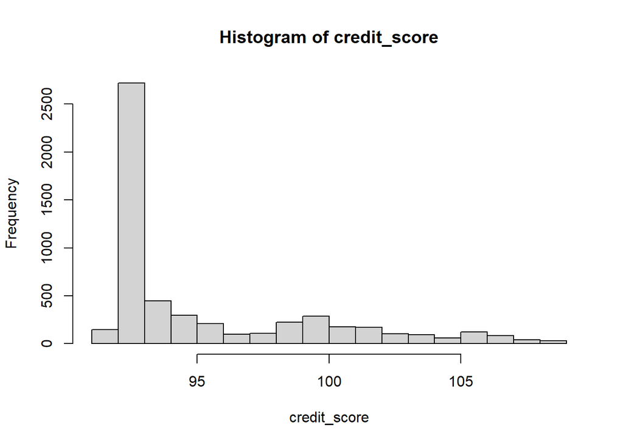

```r
credit_score <-100+2*z_score
hist(credit_score)
```

#RANDOM FOREST

```r
train.data$default.payment.next.month <- as.factor(train.data$default.payment.next.month)
```

```r
#Random Forest
rf = train(default.payment.next.month ~ .,
           data = train.data,
           method = "rf",
           trControl = trainControl(method = "cv", number = 10,allowParallel = FALSE),
           metric = "Accuracy")
rf
```

```
## Random Forest
##
## 5409 samples
##   20 predictor
##    2 classes: '0', '1'
##
## No pre-processing
## Resampling: Cross-Validated (10 fold)
## Summary of sample sizes: 4867, 4868, 4867, 4869, 4868, 4868, ...
## Resampling results across tuning parameters:
##
##   mtry  Accuracy   Kappa
##    2    0.8800234  0.5747717
##   12    0.8798348  0.5932769
##   22    0.8785396  0.5935270
##
## Accuracy was used to select the optimal model using the largest value.
## The final value used for the model was mtry = 2.
```

```r
# Dự đoán xác suất của lớp 1 (default = 1)
test.probrf <- predict(rf, newdata = test.data, type = "prob")[, "1"]
# Phân loại các kết quả (0 hoặc 1) dựa trên ngưỡng 0.5
test.predrf <- ifelse(test.probrf > 0.5, 1, 0)
# Chuyển test.predrf thành factor để so sánh với biến Default trong test.data
test.predrf <- as.factor(test.predrf)
# Confusion matrix để đánh giá hiệu suất mô hình
confusionMatrix(test.predrf, factor(test.data$default.payment.next.month,levels=c(0,1)), positive = "1")
```

```
## Confusion Matrix and Statistics
##
##           Reference
## Prediction    0    1
##          0 1768  204
##          1   98  247
##
##                Accuracy : 0.8697
##                  95% CI : (0.8553, 0.8831)
##     No Information Rate : 0.8054
##     P-Value [Acc > NIR] : < 2.2e-16
##
##                   Kappa : 0.5436
##
##  Mcnemar's Test P-Value : 1.521e-09
##
##             Sensitivity : 0.5477
##             Specificity : 0.9475
##          Pos Pred Value : 0.7159
##          Neg Pred Value : 0.8966
##              Prevalence : 0.1946
##          Detection Rate : 0.1066
##    Detection Prevalence : 0.1489
##       Balanced Accuracy : 0.7476
##
##        'Positive' Class : 1
##
```

```r
# Độ quan trọng của các biến trong mô hình Random Forest
varImp(rf)
```

```
## rf variable importance
##
##   only 20 most important variables shown (out of 22)
##
##            Overall
## PAY_1      100.000
## PAY_2       51.213
## PAY_4       33.896
## PAY_5       31.205
## PAY_3       30.971
## PAY_6       29.790
## PAY_AMT1    28.468
## PAY_AMT2    24.700
## PAY_AMT3    23.230
## BILL_AMT6   23.126
## BILL_AMT2   22.328
## BILL_AMT1   21.929
## BILL_AMT5   21.813
## BILL_AMT3   21.558
## PAY_AMT4    21.266
## BILL_AMT4   21.180
## PAY_AMT5    19.632
## PAY_AMT6    17.984
## LIMIT_BAL   15.492
## EDUCATION2   3.927
```

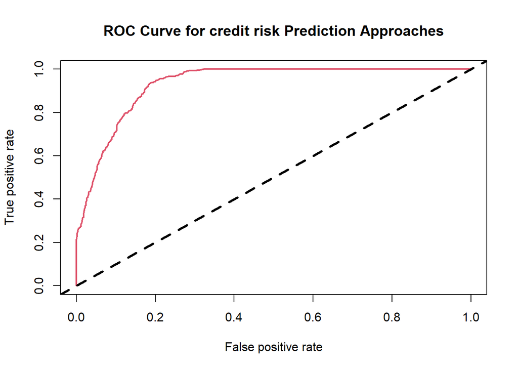

```r
#vẽ đường cong ROC
# ROC curve
roc.pred3 <- prediction(predictions = test.probrf, labels = test.data$default.payment.next.month)
roc.perf3 <- performance(roc.pred3, measure = "tpr", x.measure = "fpr")
# Tính chỉ số AUROC
AUROC_value3 <- roc.perf3@y.values[[1]]
auc3 <- as.numeric(performance(roc.pred3, measure = "auc")@y.values)
plot(roc.perf3, main = "ROC Curve for credit risk Prediction Approaches", col = 2, lwd = 2)
abline(a = 0, b = 1, lwd = 3, lty = 2, col = 1)
```

```r
auc3
```

```
## [1] 0.9324789
```

```r
gini3<- 2*auc3 - 1
gini3
```

```
## [1] 0.8649577
```

#K-Nearest Neighbour

```r
knn_fit = train(default.payment.next.month ~.,
                data = train.data,trControl=trainControl(method="cv",number=10,allowParallel = FALSE), method = "knn",tuneLength = 9)
print(knn_fit,digits=3)
```

```
## k-Nearest Neighbors
##
## 5409 samples
##   20 predictor
##    2 classes: '0', '1'
##
## No pre-processing
## Resampling: Cross-Validated (10 fold)
## Summary of sample sizes: 4868, 4868, 4867, 4869, 4867, 4869, ...
## Resampling results across tuning parameters:
##
##   k   Accuracy  Kappa
##    5  0.795     0.1630
##    7  0.800     0.1542
##    9  0.802     0.1375
##   11  0.804     0.1239
##   13  0.803     0.1115
##   15  0.802     0.0889
##   17  0.802     0.0767
##   19  0.804     0.0816
##   21  0.804     0.0759
##
## Accuracy was used to select the optimal model using the largest value.
## The final value used for the model was k = 11.
```

```r
test.probk=predict(knn_fit,newdata=test.data,type="prob")[,"1"]
test.predk=ifelse(test.probk>0.5,1,0)
test.predk=as.factor(test.predk)
confusionMatrix(test.predk,factor(test.data$default.payment.next.month,levels=c(0,1)),positive = "1")
```

```
## Confusion Matrix and Statistics
##
##           Reference
## Prediction    0    1
##          0 1815  398
##          1   51   53
##
##                Accuracy : 0.8062
##                  95% CI : (0.7895, 0.8221)
##     No Information Rate : 0.8054
##     P-Value [Acc > NIR] : 0.4707
##
##                   Kappa : 0.1273
##
##  Mcnemar's Test P-Value : <2e-16
##
##             Sensitivity : 0.11752
##             Specificity : 0.97267
##          Pos Pred Value : 0.50962
##          Neg Pred Value : 0.82015
##              Prevalence : 0.19465
##          Detection Rate : 0.02287
##    Detection Prevalence : 0.04489
##       Balanced Accuracy : 0.54509
##
##        'Positive' Class : 1
##
```

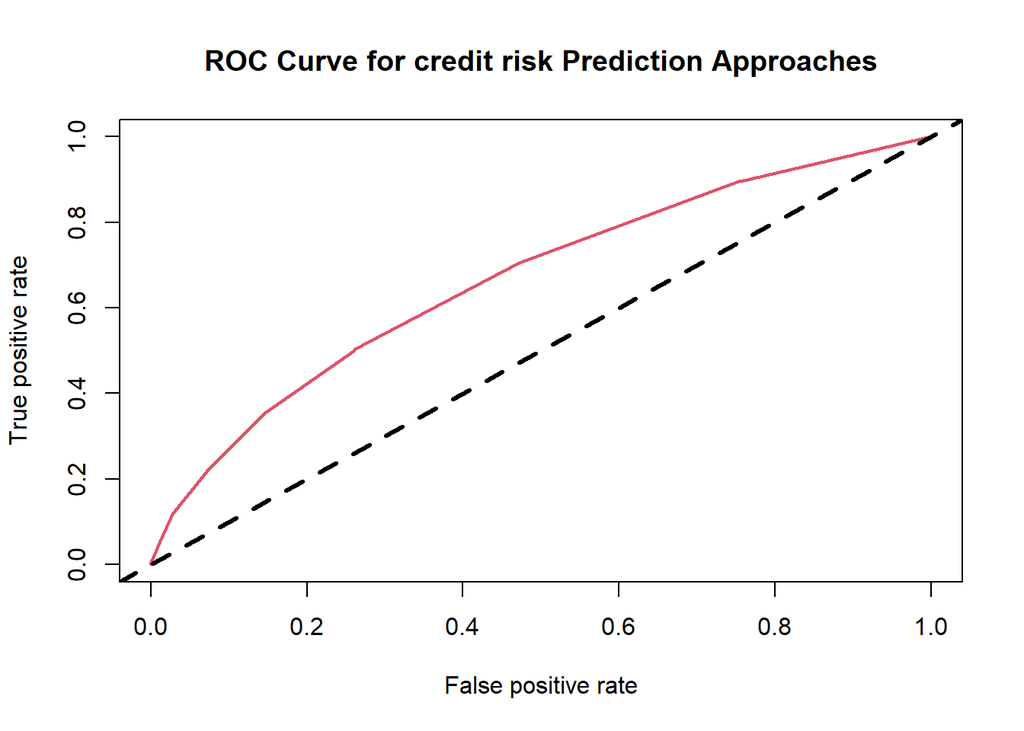

```r
#vẽ đường cong ROC
# ROC curve
roc.pred4 <- prediction(predictions = test.probk, labels = test.data$default.payment.next.month)
roc.perf4 <- performance(roc.pred4, measure = "tpr", x.measure = "fpr")
# Tính chỉ số AUROC
AUROC_value4<- roc.perf4@y.values[[1]]
auc4 <- as.numeric(performance(roc.pred4, measure = "auc")@y.values)
plot(roc.perf4, main = "ROC Curve for credit risk Prediction Approaches", col = 2, lwd = 2)
abline(a = 0, b = 1, lwd = 3, lty = 2, col = 1)
```

```r
auc4
```

```
## [1] 0.6660131
```

```r
gini4<- 2*auc4 - 1
gini4
```

```
## [1] 0.3320262
```